# Stock Market Analysis Project

## Daily Percentage Change

First we will begin by calculating the daily percentage change. Daily percentage change is defined by the following formula:

$ r_t = \frac{p_t}{p_{t-1}} -1$

This defines r_t (return at time t) as equal to the price at time t divided by the price at time t-1 (the previous day) minus 1. Basically this just informs you of your percent gain (or loss) if you bought the stock on day and then sold it the next day. While this isn't necessarily helpful for attempting to predict future values of the stock, its very helpful in analyzing the volatility of the stock. If daily returns have a wide distribution, the stock is more volatile from one day to the next. Let's calculate the percent returns and then plot them with a histogram, and decide which stock is the most stable!

**Create a new column for each dataframe called returns. This column will be calculated from the Close price column. There are two ways to do this, either a simple calculation using the .shift() method that follows the formula above, or you can also use pandas' built in pct_change method.**

```python
# Method 1: Using shift
maruti['returns'] = (maruti['Close'] / maruti['Close'].shift(1) ) - 1
```

```python
maruti.head()
```

| Date | Open | High | Low | Last | Close | Total Trade Quantity | Turnover (Lacs) | returns |
| --- | --- | --- | --- | --- | --- | --- | --- | --- |
| 2013-01-01 | 1497.0 | 1524.00 | 1484.95 | 1515.00 | 1514.40 | 446063.0 | 6729.15 | NaN |
| 2013-01-02 | 1518.8 | 1566.00 | 1518.80 | 1564.00 | 1557.40 | 801361.0 | 12402.67 | 0.028394 |
| 2013-01-03 | 1567.0 | 1567.00 | 1540.30 | 1541.40 | 1543.30 | 584243.0 | 9046.61 | -0.009054 |
| 2013-01-04 | 1542.0 | 1558.90 | 1539.50 | 1545.00 | 1545.45 | 361754.0 | 5605.03 | 0.001393 |
| 2013-01-07 | 1553.5 | 1601.75 | 1553.50 | 1583.95 | 1584.60 | 951298.0 | 15115.73 | 0.025332 |

```python
#or use the predefined function
maruti['returns'] = maruti['Close'].pct_change(1)
```

```python
# Now repeat for the other dataframes
mahindra['returns'] = mahindra['Close'].pct_change(1)
tata['returns'] = tata['Close'].pct_change(1)
```

```python
mahindra.head()
```

| Date | Open | High | Low | Last | Close | Total Trade Quantity | Turnover (Lacs) | MA50 | MA200 | returns |
| --- | --- | --- | --- | --- | --- | --- | --- | --- | --- | --- |
| 2013-01-01 | 937.00 | 944.00 | 934.90 | 942.10 | 941.80 | 385110.0 | 3622.41 | NaN | NaN | NaN |
| 2013-01-02 | 945.00 | 947.85 | 933.50 | 936.75 | 938.60 | 1030136.0 | 9664.42 | NaN | NaN | -0.003398 |
| 2013-01-03 | 943.00 | 943.00 | 932.10 | 933.00 | 936.40 | 951452.0 | 8908.80 | NaN | NaN | -0.002344 |
| 2013-01-04 | 932.65 | 943.70 | 929.35 | 943.00 | 941.25 | 957108.0 | 8971.15 | NaN | NaN | 0.005179 |
| 2013-01-07 | 947.80 | 957.75 | 939.95 | 953.00 | 954.15 | 1261956.0 | 12026.26 | NaN | NaN | 0.013705 |

```python
tata.head()
```

| Date | Open | High | Low | Last | Close | Total Trade Quantity | Turnover (Lacs) | returns |
| --- | --- | --- | --- | --- | --- | --- | --- | --- |
| 2013-01-01 | 316.0 | 318.30 | 314.50 | 316.60 | 316.75 | 3938243.0 | 12456.50 | NaN |
| 2013-01-02 | 318.5 | 320.95 | 316.25 | 317.50 | 318.00 | 6855751.0 | 21809.46 | 0.003946 |
| 2013-01-03 | 320.0 | 321.75 | 317.15 | 318.00 | 318.10 | 6099593.0 | 19461.11 | 0.000314 |
| 2013-01-04 | 318.5 | 318.50 | 313.20 | 315.15 | 315.40 | 8870505.0 | 27938.01 | -0.008488 |
| 2013-01-07 | 317.8 | 318.60 | 312.60 | 313.35 | 313.25 | 4890565.0 | 15425.03 | -0.006817 |

**Now plot a histogram of each companies returns. Either do them separately, or stack them on top of each other. Which stock is the most "volatile"? (as judged by the variance in the daily returns we will discuss volatility in a lot more detail in future lectures.)**

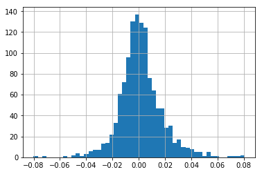

```python
maruti['returns'].hist(bins=50)
```

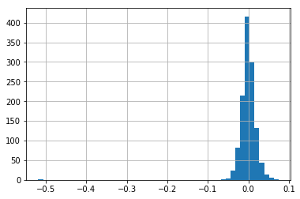

```python
mahindra['returns'].hist(bins=50)
```

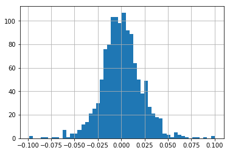

```python
tata['returns'].hist(bins=50)
```

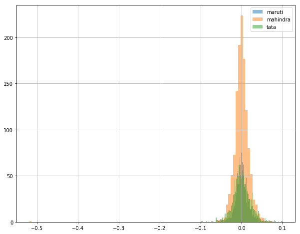

```python
maruti['returns'].hist(bins=100,label='maruti',figsize=(10,8),alpha=0.5)
mahindra['returns'].hist(bins=100,label='mahindra',alpha=0.5)
tata['returns'].hist(bins=100,label='tata',alpha=0.5)
plt.legend()
```

**Try also plotting a KDE instead of histograms for another view point. Which stock has the widest plot?**

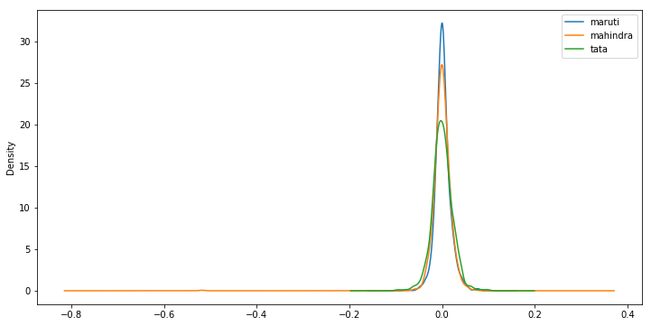

```python
maruti['returns'].plot(kind='kde',label='maruti',figsize=(12,6))
mahindra['returns'].plot(kind='kde',label='mahindra')
tata['returns'].plot(kind='kde',label='tata')
plt.legend()
```

**Try also creating some box plots comparing the returns.**

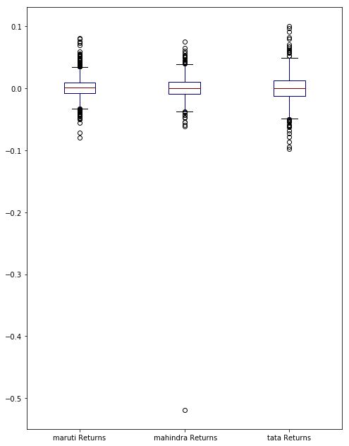

```python
box_df = pd.concat([maruti['returns'],mahindra['returns'],tata['returns']],axis=1)
box_df.columns = ['maruti Returns',' mahindra Returns','tata Returns']
box_df.plot(kind='box',figsize=(8,11),colormap='jet')
```

## Comparing Daily Returns between Stocks

** Create a scatter matrix plot to see the correlation between each of the stocks daily returns. This helps answer the questions of how related the car companies are.

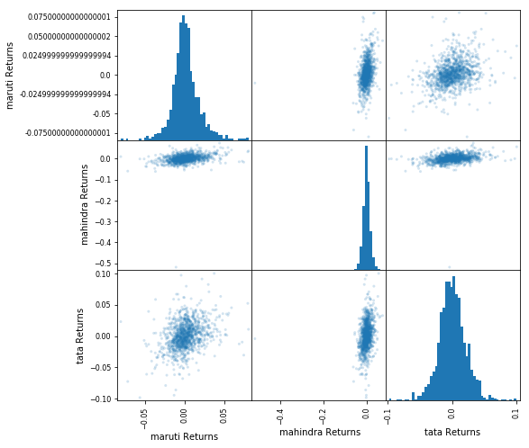

```python
scatter_matrix(box_df,figsize=(8,8),alpha=0.2,hist_kwds={'bins':50});
```

**It looks like maruti and tata do have some sort of possible relationship, let's plot just these two against eachother in scatter plot to view this more closely!**

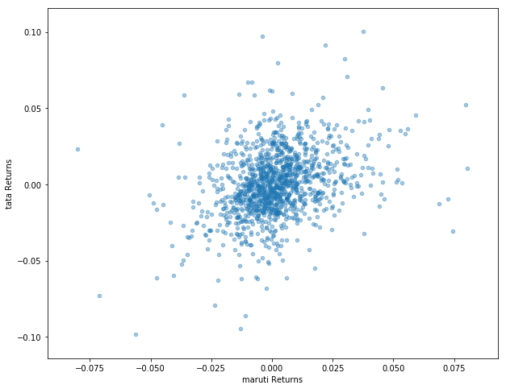

```python
box_df.plot(kind='scatter',x='maruti Returns',y='tata Returns',alpha=0.4,figsize=(10,8))
```

## Cumulative Daily Returns

With daily cumulative returns, the question we are trying to answer is the following, if I invested $1 in the company at the beginning of the time series, how much would is be worth today? This is different than just the stock price at the current day, because it will take into account the daily returns. Keep in mind, our simple calculation here won't take into account stocks that give back a dividend. Let's look at some simple examples:

Lets us say there is a stock 'ABC' that is being actively traded on an exchange. ABC has the following prices corresponding to the dates given

```
Date                        Price
01/01/2018                   10
01/02/2018                   15
01/03/2018                   20
01/04/2018                   25
```

**Daily Return** : Daily return is the profit/loss made by the stock compared to the previous day. (This is what ew just calculated above). A value above one indicates profit, similarly a value below one indicates loss. It is also expressed in percentage to convey the information better. (When expressed as percentage, if the value is above 0, the stock had give you profit else loss). So for the above example the daily returns would be

```
Date                         Daily Return                  %Daily Return
01/01/2018                 10/10 =  1                          -
01/02/2018                 15/10 =  3/2                       50%
01/03/2018                 20/15 =  4/3                       33%
01/04/2018                 25/20 =  5/4                       20%
```

**Cumulative Return**: While daily returns are useful, it doesn't give the investor a immediate insight into the gains he had made till date, especially if the stock is very volatile. Cumulative return is computed relative to the day investment is made. If cumulative return is above one, you are making profits else you are in loss. So for the above example cumulative gains are as follows

```
Date                       Cumulative Return         %Cumulative Return
01/01/2018                  10/10 =  1                         100 %
01/02/2018                  15/10 =  3/2                       150 %
01/03/2018                  20/10 =  2                         200 %
01/04/2018                  25/10 =  5/2                       250 %
```

The formula for a cumulative daily return is:

$ i_i = (1+r_t) * i_{t-1} $

Here we can see we are just multiplying our previous investment at i at t-1 by 1+our percent returns. Pandas makes this very simple to calculate with its cumprod() method. Using something in the following manner:

```
df[daily_cumulative_return] = ( 1 + df[pct_daily_return] ).cumprod()
```

**Create a cumulative daily return column for each car company's dataframe.**

```python
maruti['Cumulative Return'] = (1 + maruti['returns']).cumprod()
```

```python
maruti.head()
```

| Date | Open | High | Low | Last | Close | Total Trade Quantity | Turnover (Lacs) | returns | Cumulative Return |
| --- | --- | --- | --- | --- | --- | --- | --- | --- | --- |
| 2013-01-01 | 1497.0 | 1524.00 | 1484.95 | 1515.00 | 1514.40 | 446063.0 | 6729.15 | NaN | NaN |
| 2013-01-02 | 1518.8 | 1566.00 | 1518.80 | 1564.00 | 1557.40 | 801361.0 | 12402.67 | 0.028394 | 1.028394 |
| 2013-01-03 | 1567.0 | 1567.00 | 1540.30 | 1541.40 | 1543.30 | 584243.0 | 9046.61 | -0.009054 | 1.019083 |
| 2013-01-04 | 1542.0 | 1558.90 | 1539.50 | 1545.00 | 1545.45 | 361754.0 | 5605.03 | 0.001393 | 1.020503 |
| 2013-01-07 | 1553.5 | 1601.75 | 1553.50 | 1583.95 | 1584.60 | 951298.0 | 15115.73 | 0.025332 | 1.046355 |

```python
mahindra['Cumulative Return'] = (1 + mahindra['returns']).cumprod()
tata['Cumulative Return'] = (1 + tata['returns']).cumprod()
```

```python
mahindra.head()
```

| Date | Open | High | Low | Last | Close | Total Trade Quantity | Turnover (Lacs) | MA50 | MA200 | returns | Cumulative Return |
| --- | --- | --- | --- | --- | --- | --- | --- | --- | --- | --- | --- |
| 2013-01-01 | 937.00 | 944.00 | 934.90 | 942.10 | 941.80 | 385110.0 | 3622.41 | NaN | NaN | NaN | NaN |
| 2013-01-02 | 945.00 | 947.85 | 933.50 | 936.75 | 938.60 | 1030136.0 | 9664.42 | NaN | NaN | -0.003398 | 0.996602 |
| 2013-01-03 | 943.00 | 943.00 | 932.10 | 933.00 | 936.40 | 951452.0 | 8908.80 | NaN | NaN | -0.002344 | 0.994266 |
| 2013-01-04 | 932.65 | 943.70 | 929.35 | 943.00 | 941.25 | 957108.0 | 8971.15 | NaN | NaN | 0.005179 | 0.999416 |
| 2013-01-07 | 947.80 | 957.75 | 939.95 | 953.00 | 954.15 | 1261956.0 | 12026.26 | NaN | NaN | 0.013705 | 1.013113 |

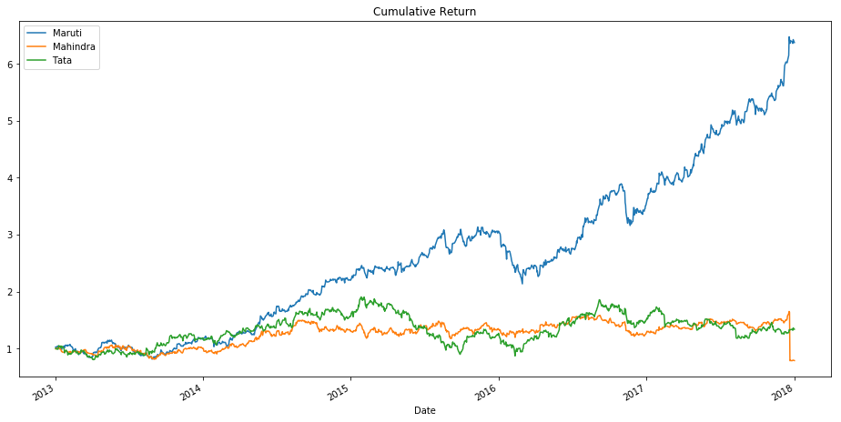

```python
maruti['Cumulative Return'].plot(label='Maruti',figsize=(16,8),title='Cumulative Return')
mahindra['Cumulative Return'].plot(label='Mahindra')
tata['Cumulative Return'].plot(label='Tata')
plt.legend()
```

That's it! We have completed basic analysis which is more focused on learning tools of trade. In part two we will really dive into functionality designed for time series, quantitative analysis, algorithmic trading, and much more.